# The Politics of Corruption

Lecture 12: Organized Crime, Violence, and State Capture

Bogdan G. Popescu

bgpopescu@tec.mx

Tecnológico de Monterrey

## Today

You have just watched it happen to one man. The question for the hour:

**How do criminal organizations influence public officials — and what happens when that arrangement breaks?**

By the end of this session you should be able to:

- Explain *plata o plomo*: why bribes and bullets are substitutes
- Explain how party alternation broke Mexico’s state–cartel protection pacts
- Predict how enforcement crackdowns reshape trafficking routes and violence

One warning: today’s material is close to home for many of you. Speak only as much as you want to.

# I. When Crime Competes for Governance

## Diego got what he wanted. Or did he?

Until now, Diego paid people to get things done. This time, he was paying someone to **avoid being hurt**.

- For months, Diego paid one criminal group. The arrangement was illegal, but **predictable**.
- He voted for a mayor who promised to fight organized crime.
- The police arrested the collector. Diego thought his problems were over.
- Instead, **two men showed up**, each demanding payment and threatening consequences.

**Why did Diego become less safe when the government finally confronted organized crime?**

And what does this tell us about the relationship between **criminal organizations, politicians, and violence**?

Diego’s story suggests something troubling: **breaking a criminal arrangement can sometimes produce more violence, not less.**

## Mexico: the timing is the puzzle

Diego’s story is fictional. But Mexico experienced a real transformation: the PRI gradually lost its monopoly on political power.

What happened to violence?

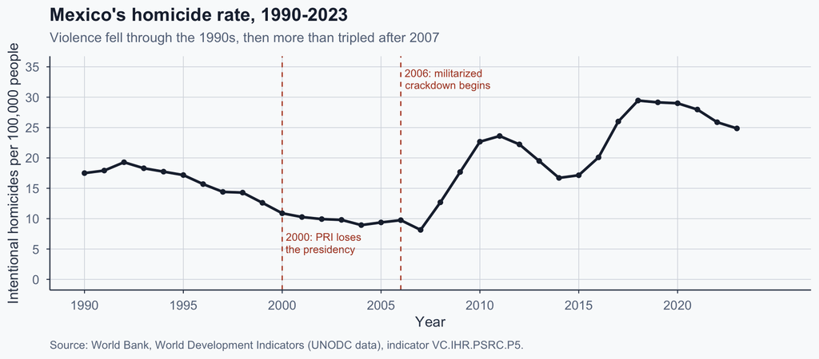

## Mexico: the timing is the puzzle

- **1989 onward:** opposition parties began winning governorships
- **2000:** the PRI lost the presidency after 71 years
- **2007:** homicide rates reached their lowest point in the series
- **After 2007:** violence increased dramatically

**If political alternation disrupted criminal protection arrangements, why did violence take so long to surge?**

## The gray zone of criminality

Criminal organizations do not only break rules — they **make** them. They collect payments, offer protection, and punish those who defy their authority. This is **criminal governance**.

But they rarely govern alone. State officials may tolerate, protect, or cooperate with them.

The competition is not simply crime *versus* order, but **who** supplies it — and sometimes **the state and criminals do so together**.

```
flowchart LR
  S["State security<br/>agents"]
  C["Criminal<br/>entrepreneurs"]
  Z["THE GRAY ZONE<br/>informal bargains"]
  R["Rules about<br/>who operates<br/>where"]
  Q["Less open violence<br/>while bargains hold"]

  S --> Z
  C --> Z
  Z --> R
  R -.-> Q

  classDef st fill:#e2eaf3,stroke:#334155,color:#1e293b
  classDef cr fill:#f7e2db,stroke:#b44527,color:#1e293b
  classDef gz fill:#f0e6c9,stroke:#b7943a,color:#1e293b
  classDef ok fill:#e2ede9,stroke:#4a7c6f,color:#1e293b

  class S st
  class C cr
  class Z gz
  class R,Q ok
```

Concept and wording from Trejo and Ley (2020, ch. 1).

## So what?

- Organized crime needs officials — it cannot operate on violence alone
- The gray zone is an **exchange**, and exchanges have prices
- So we should ask: what does capturing an official actually **cost**?
- And what changes when the buyer can also shoot?

Next: a simple model that answers both questions.

# II. Plata o Plomo: The Logic of Armed Influence

## Same officer. Same favor.

A police officer controls the checkpoint on the road outside Diego’s construction yard.

Two trucks arrive on different days. Both have incomplete paperwork. Letting either through could cost the officer his job.

- **Monday:** Diego asks the officer to wave his truck through. The officer demands **100** to take the risk. Diego pays.
- **Tuesday:** A cartel driver arrives with the same problem. He offers **40**.
- The officer refuses. The driver leans closer: **“You know what happens to people who get in our way.”**

**Why might the officer accept 40 from the cartel after demanding 100 from Diego?**

## The price of saying yes

The officer faces the same personal cost in both situations: **c = 100**.

- **Diego:** Can only offer money. He must pay **b = 100**.
- **The cartel:** Can offer money **and threaten punishment**.
- If the threatened punishment is worth **p = 60** to the officer, the cartel only needs to pay **b = 40**.

**The cartel did not make corruption less risky. It made refusing more dangerous.**

## The same decision, bought two ways

The group minimises γβ(c − p) + (1 − γ)ρ(p), so it leans on whichever instrument is cheaper at the margin. Shown with quadratic costs and γ = ½, giving p* = βc/(β + ρ) — which depends only on the *ratio* β/ρ, so one dial does it: making money dearer and making fear cheaper are the same move. The slider starts at the split above. Setting c = 100 is a normalisation, not a measurement: the same scale-free property means nothing here turns on whether the officer’s price is a month’s salary or a year’s — only the split is a prediction. Dal Bó, Dal Bó and Di Tella (2006), Lemma 3a and Propositions 7–8. Note the arrow and the red bar are always the same length: the cash saved is exactly the fear supplied.

## Result: violence makes influence cheaper

- Fear substitutes for cash, so an armed group never pays full price — only **c − p**
- Influence is cheaper for whoever can threaten, so **more groups can afford it**
- And the money you can see **understates** the influence actually bought

“Politicians being coerced will sell their favors relatively cheaply.”

Dal Bó, Dal Bó and Di Tella (2006), Propositions 2, 4 and 5 — also their answer to Tullock’s puzzle about how little is spent on lobbying.

## Can fighting bribery make intimidation worse?

Back at the checkpoint. The cartel offers **40 in cash** and **60 in threatened punishment** to get its truck through. The government introduces two reforms.

**A. Trace the money.** Bribes become riskier to pay. But threatening the officer is just as easy as before.

- If the cartel keeps trying, it may switch to **20 in cash and 80 in threats**

**B. Protect the officer.** The government protects his family and makes intimidation harder. Paying bribes is just as easy as before.

- If the cartel keeps trying, it may switch to **67 in cash and 33 in threats**

**The lesson:** when one instrument becomes more expensive, criminal groups may substitute the other.

And notice what A does to the official statistics: **fewer bribes are observed, even though the officer is still being coerced.**

## When does the cartel give up?

There is one thing our examples have assumed: **the cartel still wants to buy the officer’s cooperation.** But influencing an official costs money and resources.

- **Make bribes and threats more expensive.** Eventually, influencing the officer may cost more than the cartel gains
- **Take away the decision.** Introduce automatic, recorded inspections — the officer can no longer wave trucks through on his own
- If the officer has nothing valuable to offer, why pay or threaten him?

**Two ways to fight criminal influence: make it more expensive, or make it less valuable.**

This explains **armed** influence, not influence in general:  
- Diego needs that officer just as badly, and still pays full price — what he lacks is any credible way to hurt him.

## So what?

- The model says armed influence is **cheap**, and mostly **quiet**
- But the arrangement is a handshake: informal, unwritten, no court behind it
- So it lasts only as long as the people who shook hands stay in office

We now know why a cartel can buy an official cheaply. **But what happens when the politicians protecting that cartel lose their jobs?**

# III. Mexico: How Democratization Broke the Pact

## The old protection bargain

```
flowchart LR
  A["PRI dominates<br/>state politics"]
  B["Police and prosecutors<br/>protect traffickers"]
  C["Traffickers pay<br/>and follow informal rules"]
  D["Less open fighting<br/>between cartels"]

  A --> B
  B --> C
  C --> D

  classDef pol fill:#e2eaf3,stroke:#334155,stroke-width:3px,color:#1e293b
  classDef crm fill:#f7e2db,stroke:#b44527,stroke-width:3px,color:#1e293b
  classDef out fill:#e2ede9,stroke:#4a7c6f,stroke-width:3px,color:#1e293b
  class A,B pol
  class C crm
  class D out
```

Author’s illustration of Trejo and Ley (2020, ch. 1). Say the rest aloud: protection let traffickers operate, and the informal rules kept them from fighting each other over it.

## The shock: elections start changing governors

- 1989: Ernesto Ruffo Appel wins Baja California — the first non-PRI governor since 1929
- Opposition wins spread across states through the 1990s
- 2000: the PRI loses the presidency after 71 years
- Incoming governors replaced police chiefs and state prosecutors
- Those were exactly the offices where protection had been negotiated

Democratization advanced **faster than police and judicial reform**.

Imagine you control a valuable trafficking route. For years, the governor’s police have protected your operations.

Then an opposition governor wins and replaces the police chief.

**Your rivals know you may no longer be protected. What happens next?**

## Trejo and Ley: how a pact becomes a war

```
%%{init: {"theme":"base","themeVariables":{"fontSize":"20px","fontFamily":"Helvetica Neue, Helvetica, Arial, sans-serif","primaryColor":"#f1f5f9","primaryTextColor":"#1e293b","primaryBorderColor":"#334155","lineColor":"#64748b"},"flowchart":{"useMaxWidth":true,"htmlLabels":false,"nodeSpacing":170,"r…
flowchart LR
  A["Opposition<br/>governor wins"]
  B["Police and<br/>prosecutors replaced"]
  C["Old protection<br/>becomes uncertain"]
  D["Cartels build<br/>private militias"]
  E["Rivals fight<br/>for territory"]

  A --> B
  B --> C
  C --> D
  D --> E

  classDef pol fill:#e2eaf3,stroke:#334155,stroke-width:3px,color:#1e293b
  classDef unc fill:#f0e6c9,stroke:#b7943a,stroke-width:4px,color:#1e293b
  classDef war fill:#f7e2db,stroke:#b44527,stroke-width:3px,color:#1e293b
  class A,B pol
  class C unc
  class D,E war
```

Author’s illustration of Trejo and Ley (2018, 2020). Worth saying aloud rather than drawing: once the fighting starts it feeds the uncertainty that began it.

## Territory is the prize

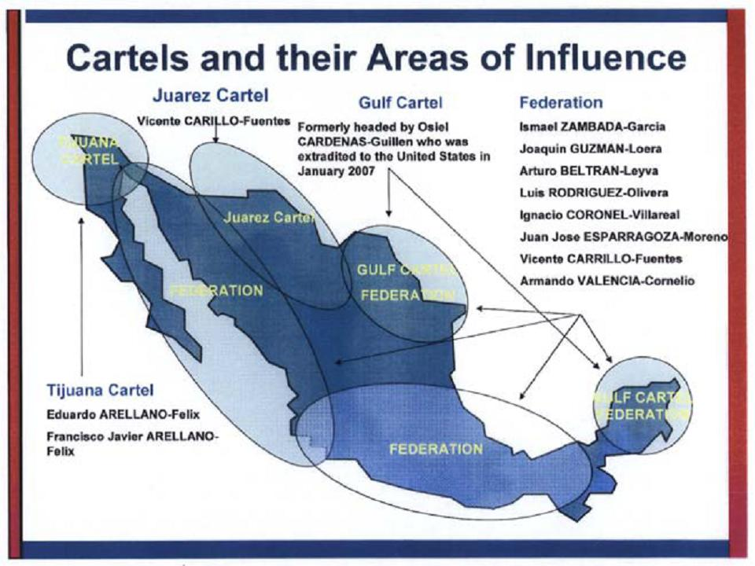

Cartels and their claimed areas of influence in Mexico, 2008

This is a snapshot **well into the escalation**: still a handful of large blocs.

What the next decade did to it: Taking out leaders splits organizations rather than dissolving them.

## From divided to disputed

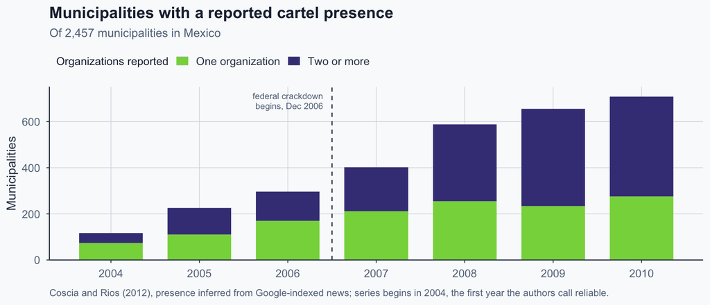

- 2004: **116** municipalities, 42 of them with more than one organization
- 2010: **709** municipalities, **433** of them with more than one
- From 2008 on, most cartel territory is **contested** rather than simply held

Reported presence, not presence: the measure counts municipalities where news and blog coverage named an organization, so thickening web coverage inflates the trend somewhat — the mirror image of the usual problem, where quiet coercion goes uncounted. Independent corroboration of the direction: Crisis Group’s census counts 76 armed groups in 2010 and 205 by late 2020.

## Where the contest spread

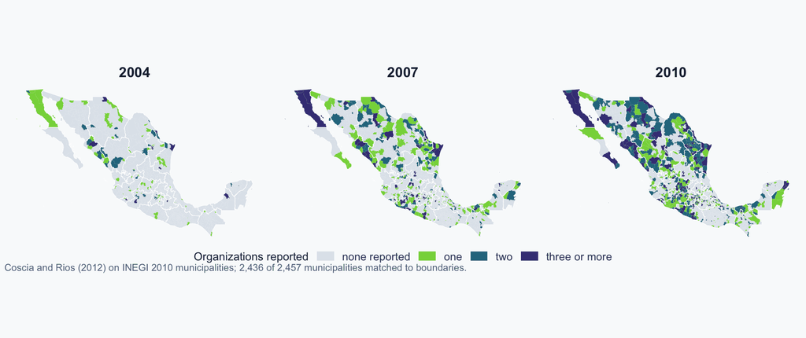

## What difference can a close election make?

Trejo and Ley studied what happens when **governors** change. Dell (2015) looks at **mayors**.

Imagine two towns holding elections:

- **Town A:** PAN loses by just 0.1 percentage points.
- **Town B:** PAN wins by just 0.1 percentage points.
- Would you expect these towns to have very different levels of violence?

Probably not. In very close elections, towns on either side should be similar **on average**.

But one gets a **PAN mayor**, and the other does not.

**Why might that matter?** Mayors appoint police chiefs. PAN mayors were more willing to confront traffickers, often with federal support.

**So what happens to violence when the PAN barely wins?**

Dell (2015). The close-election comparison identifies the effect of a PAN victory; increased enforcement is a proposed mechanism.

## The jump appears only once the mayor is sworn in

[figure not shown]

## Where the estimate comes from

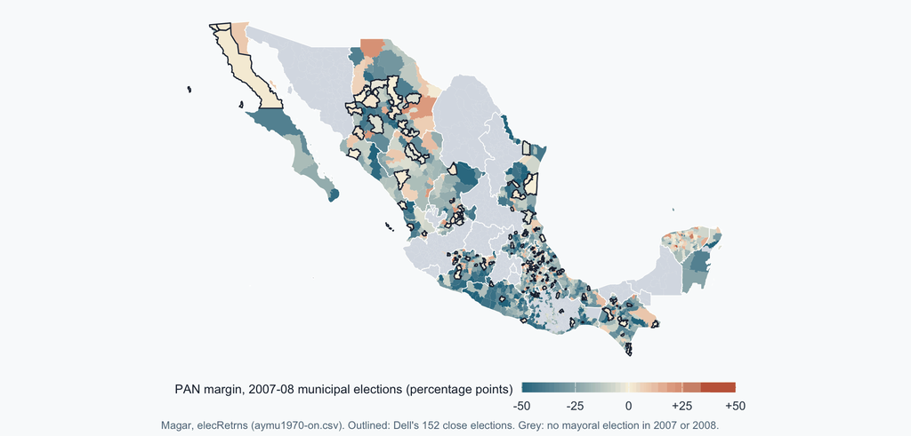

## The jump appears only once the mayor is sworn in

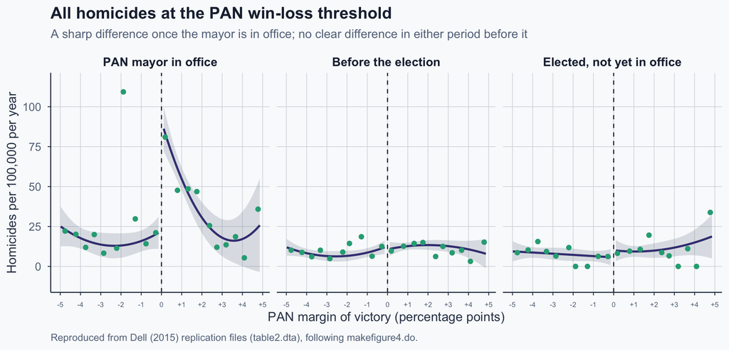

- **Left of zero:** PAN barely lost. **Right:** PAN barely won.
- **Once the mayor takes office:** violence jumps on the PAN-winning side.
- **Before the election:** no clear difference at the cutoff.
- **After the election, before inauguration:** still no clear difference.

**Why only after the new mayor takes office?**

Dell (2015), Figure 4. Close PAN victories are the treatment; increased enforcement is one proposed explanation.

## Dell (2015): the main result

Where the PAN barely won rather than barely lost, across the mayor’s term:

- **+57** overall homicides per 100,000 residents per year
- **+33** drug-trade-related homicides per 100,000 residents per year

What moved was the **intensity** of violence, not whether any occurred: the chance that *any* killing happens in a month barely budged.

The difference emerged **after the new mayor took office**, which is what points to enforcement:  
- it weakened the incumbent trafficker and opened the town to rivals.

## Seventeen years of nothing, then a cliff

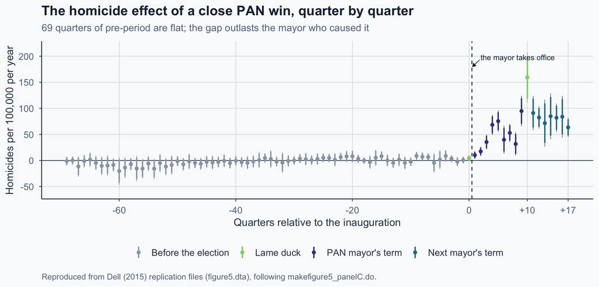

Dell’s Figure 5, panel C. Thick bars are 90% intervals, thin bars 95%. One of the 69 pre-election quarters is significant — fewer than chance alone would give.

## Why would enforcement raise violence?

```
%%{init: {"theme":"base","themeVariables":{"fontSize":"20px","fontFamily":"Helvetica Neue, Helvetica, Arial, sans-serif","primaryColor":"#f1f5f9","primaryTextColor":"#1e293b","primaryBorderColor":"#334155","lineColor":"#64748b"},"flowchart":{"useMaxWidth":true,"htmlLabels":false,"nodeSpacing":110,"r…
flowchart LR
  A["Close PAN win:<br/>new mayor,<br/>new police chief"]
  B["The trafficker<br/>holding the town<br/>is weakened"]
  C["But the route<br/>through it is still<br/>worth taking"]
  D["Is a rival<br/>close enough<br/>to take it?"]
  E["Rivals move in:<br/>war over the<br/>territory"]
  F["Nobody comes:<br/>the town stays<br/>quiet"]

  A --> B
  B --> C
  C --> D
  D -->|"borders a rival"| E
  D -->|"allies, or a local gang only"| F

  classDef pol fill:#e2eaf3,stroke:#334155,stroke-width:3px,color:#1e293b
  classDef crm fill:#f7e2db,stroke:#b44527,stroke-width:3px,color:#1e293b
  classDef unc fill:#f0e6c9,stroke:#b7943a,stroke-width:4px,color:#1e293b
  classDef ok  fill:#e2ede9,stroke:#4a7c6f,stroke-width:3px,color:#1e293b
  class A pol
  class B,C crm
  class D unc
  class E crm
  class F ok
```

Enforcement removes the **defender**, not the **prize**.

## Where should the effect be largest?

Weakening a cartel should provoke the most violence **where**? Take three guesses from the room before the next click.

## One crackdown, three towns

```
%%{init: {"theme":"base","themeVariables":{"fontSize":"20px","fontFamily":"Helvetica Neue, Helvetica, Arial, sans-serif","primaryColor":"#f1f5f9","primaryTextColor":"#1e293b","primaryBorderColor":"#334155","lineColor":"#64748b"},"flowchart":{"useMaxWidth":true,"htmlLabels":false,"nodeSpacing":120,"r…
flowchart LR
  G["Growing<br/>region"]
  A["Town A"]
  B["Town B<br/>crackdown here:<br/>costly to pass"]
  C["Town C<br/>no crackdown,<br/>no election"]
  X["U.S.<br/>crossing"]

  G --> A
  A -.->|"old route,<br/>now expensive"| B
  B -.-> X
  A ==>|"traffic<br/>re-routes"| C
  C ==> X

  classDef route fill:#e2eaf3,stroke:#334155,stroke-width:3px,color:#1e293b
  classDef hit fill:#f7e2db,stroke:#b44527,stroke-width:3px,color:#1e293b
  classDef new fill:#f0e6c9,stroke:#b7943a,stroke-width:4px,color:#1e293b
  class G,A,X route
  class B hit
  class C new
```

Town C never had a crackdown and never voted for one. **If the drugs start moving through C, what else arrives there?**

Someone already runs C. Now there is something worth taking from them.

## How a crackdown moves a route

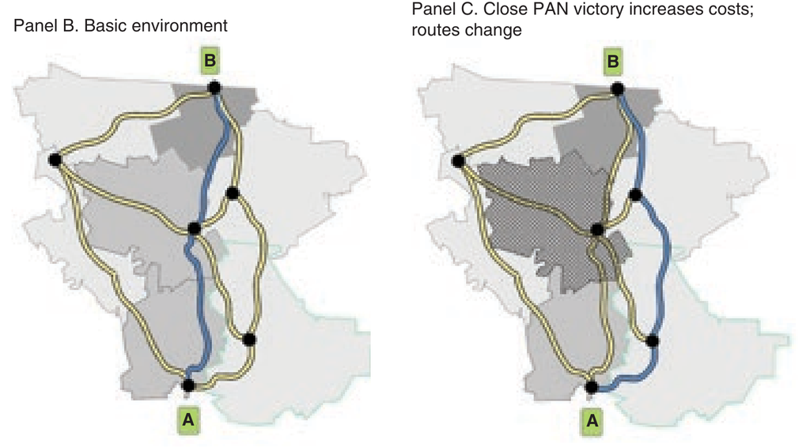

**Left, before:** the cheapest way from A to B runs straight up the middle. **Right:** a close PAN win makes the cross-hatched municipality expensive to cross, and the same trip shifts east onto a different chain of roads. Blue is the route taken, olive the roads available, dots the junctions.

## The routes, rebuilt from her data

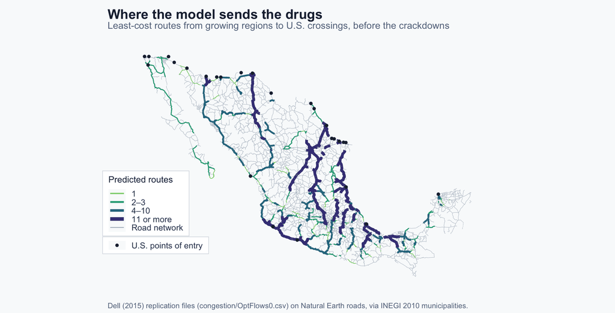

## Where the traffic went

A crackdown makes one trafficking route more dangerous. But the drugs still need to reach the U.S.

Dell models Mexico’s road network to predict where traffickers would go instead.

- **Do they actually reroute?** Where the model predicts a new route, the value of drug seizures rises **18%**.
- **Does violence follow?** The monthly probability of a drug-related killing rises from **4.8% to 6.2%**.
- **Where is violence greatest?** There is some evidence of larger increases where multiple routes converge.

**A crackdown in one town can increase violence somewhere else.**

The government may disrupt a trafficking route without stopping the trafficking itself.

Dell (2015), Tables 6–7. Predicted routes are validated against drug seizures; evidence on violence where routes overlap is suggestive.

# IV. So What Should the State Do?

## Do these two papers tell the same story?

- Trejo and Ley: politics breaks the pact, then rivals arm
- Dell: enforcement weakens the incumbent, then rivals enter
- Different shocks, same shape: an existing equilibrium is disturbed
- Violence rises where the old order breaks, not where crime is
- Neither paper claims the old equilibrium was good for citizens

The shared lesson: **disturbing a criminal order can raise violence before it lowers it.**

## The uncomfortable question

Diego wanted the cartel gone. The police arrested its collector. But now two rival groups are threatening him.

- **Should the government have left the cartel alone?**
- Tolerating the old arrangement meant accepting extortion, corruption, and impunity.
- But dismantling it without restoring order created opportunities for rival groups.

**How can the state confront organized crime without making people like Diego less safe?**

## Takeaways

- **Plata o plomo:** threats can substitute for bribes, making political influence cheaper and harder to detect.
- **Anti-corruption reforms:** making bribery more expensive can push armed groups toward intimidation instead.
- **Political alternation:** replacing governors and security officials can disrupt criminal protection arrangements and trigger territorial wars.
- **Enforcement:** weakening a cartel can invite rival attacks and redirect trafficking — and violence — to other towns.

Three mechanisms, not one: **threats against officials, wars between cartels, and violence spilling into other towns.**

None of this means democracy causes violence or crackdowns always backfire. These effects depend on the institutions and criminal competition in place.

**Disrupting criminal control is not the same as replacing it with state control.**

## References

Acemoglu, D., De Feo, G., & De Luca, G. (2020). Weak states: Causes and consequences of the Sicilian Mafia. *The Review of Economic Studies, 87*(2), 537–581. https://doi.org/10.1093/restud/rdz009

Dal Bó, E., Dal Bó, P., & Di Tella, R. (2006). “Plata o plomo?”: Bribe and punishment in a theory of political influence. *American Political Science Review, 100*(1), 41–53. https://doi.org/10.1017/S0003055406061995

Dell, M. (2015). Trafficking networks and the Mexican drug war. *American Economic Review, 105*(6), 1738–1779. https://doi.org/10.1257/aer.20121637

Trejo, G., & Ley, S. (2018). Why did drug cartels go to war in Mexico? Subnational party alternation, the breakdown of criminal protection, and the onset of large-scale violence. *Comparative Political Studies, 51*(7), 900–937. https://doi.org/10.1177/0010414017720703

Trejo, G., & Ley, S. (2020). *Votes, drugs, and violence: The political logic of criminal wars in Mexico*. Cambridge University Press. https://doi.org/10.1017/9781108894807